# Unos bibilioteka

```python
import numpy as np
from utils.data_utils import *
from utils.model_utils import *
```

# Linearno separabilne klase

## Unos podataka

```python
# Učitavanje podataka
X, y = read_data('./data/svmData_ls.csv')
```

## Linearni kernel bez regularizacije

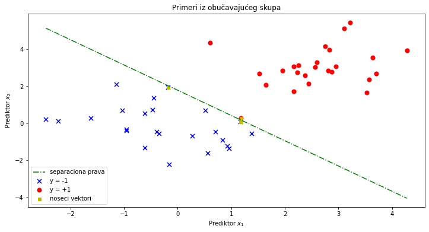

```python
# Kreiranje modela bez regularizacije
svm = SVM()

# Obučavanje modela i prikaz klasifikovanih podatak
svm.fit(X, y, disp=True)
```

Kako su klase linearno separabilne i ne postoji regularizacija, model pokušava da savršeno razdvoji dve kase po svaku cenu. Posledica je to da je separaciona prava jako blizu odbircima jedne i druge klase. Iako su klase na posmatranom skupu savršeno razdvojene, generalizacija modela je umanjena jer model nema mogućnost da razmatra da je primer iz klase y=1 najbliže separacionoj liniji izuzetak koji treba ignorisati po cenu bolje klasifikacije novih odbiraka.

## Linearni kernel sa regularicijom

### Unakrsna validacija za izbor regularizacionog hiper-parametra

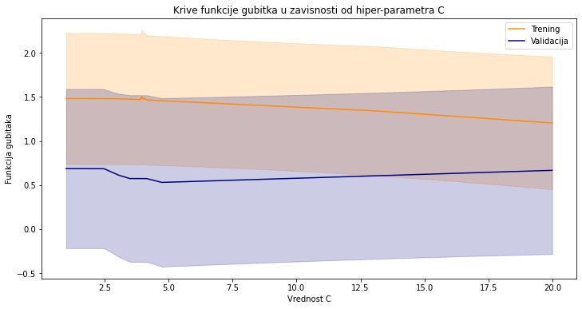

```
Minimalna vrednost funkcije gubitaka je za C=4.73
```

```python
# Moguce vrednosti hiper-parametra
c_values = [i*0.01 for i in range(100, 2000)]

# Unakrsna validacija
c_best = cross_validate(X, y, c_values, nfolds=5, disp=True)
print(f"Minimalna vrednost funkcije gubitaka je za C={c_best}")
```

Regularizacija metode nosećih vektora zahteva određivanje hiper-parametra C unakrsnom validacijom. Podaci su podeljeni na 5 strukova i posmatrana je minimalna "hinge" gubitka na validacionom skupu usrednjena po strukovima.

### Obučavanje modela sa optimalnim hiper-parametrom C

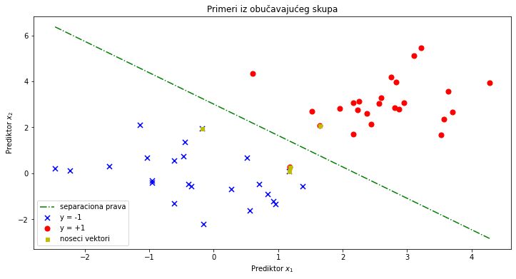

```python
# Kreiranje modela sa optimalnim hiper-parametrom C
svm = SVM(C=4.73)
# Obučavanje modela i prikaz klasifikovanih podataka
svm.fit(X, y, disp=True)
```

Po cenu jednu jednog loše klasifikovanog odbirka model je povećao marginu između klasa i samim tim uspeo da dosta bolje generalizuje.

# Nelinearno separabilni podaci - Gaussov kernel

## Unos podataka

```python
# Učitavanje podataka
X, y = read_data('./data/svmData_nls.csv')
```

## Unakrsna validacija za izbor regularizacionog hiper-parametra C i hiper-parametra $\sigma$

Posmatrane klase nisu linearno separabilne ali je uz pomoć regularizacije i kernel trika moguće razdvojiti i ovakve primere. U nastavku je razmatran Gaussov kernel koji unosi dodatni hiper-parametar $\sigma$. U prostoru hiper-parametara urađena je unakrsna validacija i posmatrana je vrednost šarka gubitka usrednjena po strukovima. Kako je prostor dvodimenzioni, moguće je vizualizovati vrednosti hinge loss-a. Grafik je prikazan u ćeliji ispod.

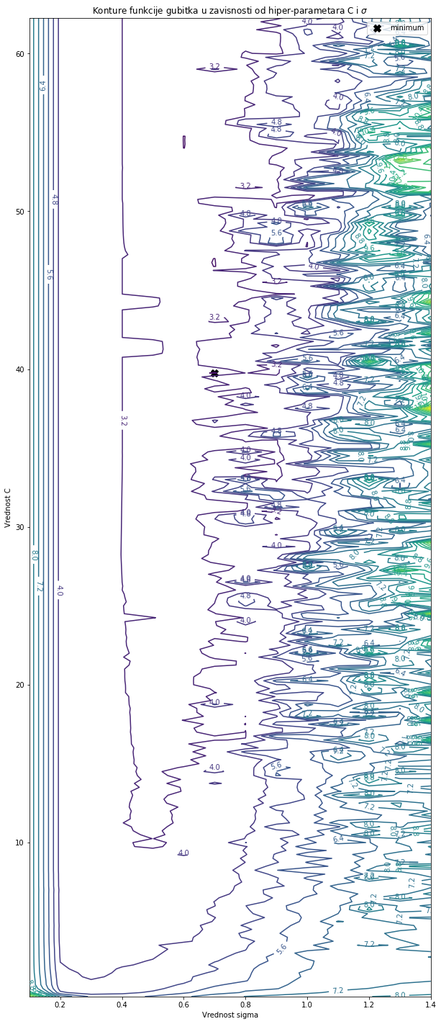

```
Minimalna vrednost funkcije gubitaka je za C=39.75, sigma=0.7000000000000001
```

```python
# Moguce vrednosti hiper-parametra
c_values = [i*0.25 for i in range(1, 250)]
sigma_values = [0.1*i for i in range(1, 15)]

# Unakrsna validacija
hyperparams = cross_validate(X, y, c_values, nfolds=5, kernel='gauss', sigma_values=sigma_values, disp=True)
print(f"Minimalna vrednost funkcije gubitaka je za C={hyperparams[0]}, sigma={hyperparams[1]}")
```

## Obučavanje modela sa optimalnim hiper-parametrima

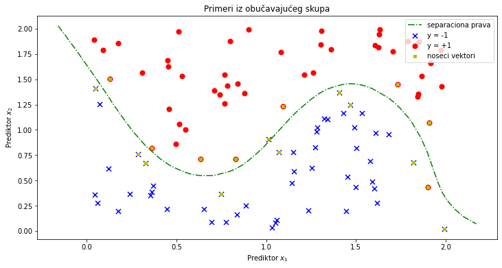

```python
# Kreiranje modela sa optimalnim hiper-parametrom C
svm = SVM(C=39.75, kernel='gauss', sigma=0.7)
# Obučavanje modela i prikaz klasifikovanih podataka
svm.fit(X, y, disp=True)
```

Uz par pogrešno klasifikovanih, model uspeva da dobro generalizuje na obučavajućem skupu. Separaciona linija nema oštre prevoje što je indikator da nije došlo do preobučavanja.